# Análise Fatorial

Equipe de Análise Multivariada

2025-03-04

# 1 Introdução à Análise Fatorial

## 1.1 Definição Conceitual

A análise fatorial é uma técnica estatística multivariada que visa identificar padrões de correlação entre um conjunto de variáveis, reduzindo-as a um número menor de dimensões ou fatores latentes.

### 1.1.1 Objetivos Principais

1. Explorar estruturas subjacentes em conjuntos de dados complexos
2. Simplificar a interpretação de múltiplas variáveis
3. Descobrir constructos ou dimensões não observáveis diretamente

## 1.2 Tipos de Análise Fatorial

### 1.2.1 Análise Fatorial Exploratória (EFA)

**Características:** - Descoberta de estruturas latentes - Sem definição prévia do número de fatores - Útil quando não há hipóteses prévias - Identificação de agrupamentos naturais de variáveis

### 1.2.2 Análise Fatorial Confirmatória (CFA)

**Características:** - Teste de hipóteses sobre estruturas fatoriais - Verificação de ajuste de modelo teórico - Utilização de índices de ajuste - Validação de modelos predefinidos

## 1.3 Aplicações em Saúde

### 1.3.1 Contextos de Aplicação

1. **Questionários de Qualidade de Vida**
   - Identificação de dimensões subjacentes
   - Validação de escalas de bem-estar
   - Redução de número de itens
2. **Escalas de Avaliação Clínica**
   - Análise de constructos complexos
   - Validação de instrumentos de diagnóstico
   - Compreensão de inter-relações entre sintomas
3. **Pesquisas Epidemiológicas**
   - Identificação de fatores de risco
   - Simplificação de análises multivariadas
   - Criação de índices compostos de vulnerabilidade

## 1.4 Pressupostos da Análise Fatorial

### 1.4.1 Requisitos Fundamentais

1. **Tamanho da Amostra**
   - Mínimo recomendado: 100-200 observações
   - Proporção: 5-10 observações por variável
2. **Matriz de Correlação**
   - Correlações significativas entre variáveis
   - Testes de verificação:
     - Teste de Esfericidade de Bartlett
     - Índice Kaiser-Meyer-Olkin (KMO)
3. **Distribuição dos Dados**
   - Normalidade aproximada
   - Verificação de assimetria e curtose
   - Linearidade entre variáveis

### 1.4.2 Estratégias para Violação de Pressupostos

- Transformação de variáveis
- Remoção de outliers
- Métodos robustos de análise
- Reavaliação da seleção de variáveis

# 2 Preparação e Processamento de Dados

## 2.1 Função de Preparação de Dados

```r
preparar_dados <- function(dados) {
  # Remoção de valores missing
  dados_limpos <- na.omit(dados)

  # Análise descritiva
  descritiva <- describe(dados_limpos)
  print(descritiva)

  return(dados_limpos)
}

# Dados simulados de exemplo
set.seed(123)
dados_saude <- data.frame(
  depressao_1 = rnorm(200, mean = 3, sd = 1),
  depressao_2 = rnorm(200, mean = 3, sd = 1),
  ansiedade_1 = rnorm(200, mean = 2, sd = 1),
  ansiedade_2 = rnorm(200, mean = 2, sd = 1),
  estresse_1 = rnorm(200, mean = 4, sd = 1),
  estresse_2 = rnorm(200, mean = 4, sd = 1)
)
```

## 2.2 Verificação de Pressupostos

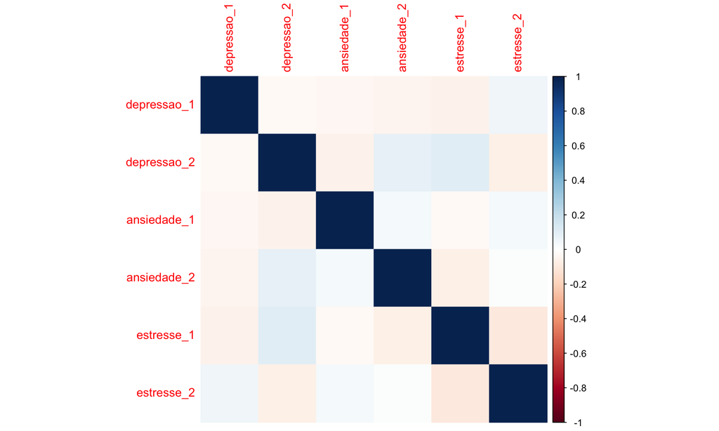

```r
# Teste de Bartlett e KMO
bartlett_teste <- cortest.bartlett(dados_saude)
kmo_teste <- KMO(dados_saude)

# Matriz de correlação
correlacao <- cor(dados_saude)
corrplot(correlacao, method = "color")
```

## 2.3 Análise Fatorial Exploratória

### 2.3.1 Definição do Número de Fatores

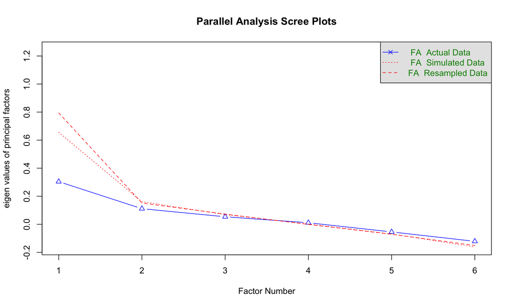

```
## Parallel analysis suggests that the number of factors =  0  and the number of components =  NA
```

```r
# Análise paralela para sugestão de fatores
fa.parallel(dados_saude,
            fm = "ml",   # Método de fatoração
            fa = "fa")   # Análise fatorial
```

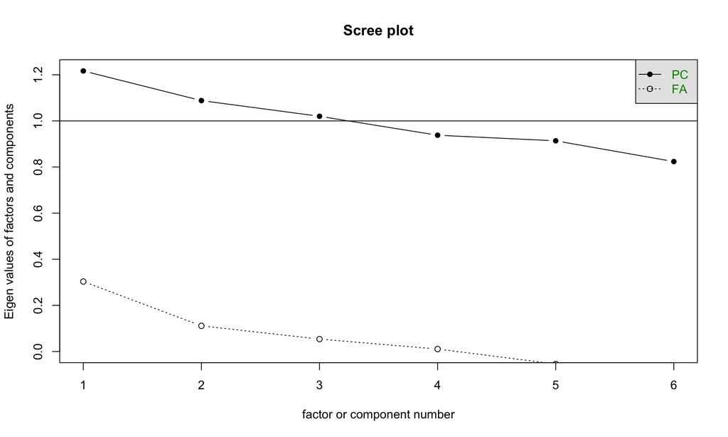

```r
# Scree plot
scree(dados_saude)
```

### 2.3.2 Extração e Rotação de Fatores

```r
# Análise Fatorial Exploratória
modelo_efa <- fa(dados_saude,
                 nfactors = 2,      # Número de fatores
                 rotate = "varimax",# Método de rotação
                 fm = "ml")          # Método de fatoração

# Visualizar resultados
print(modelo_efa)
```

```
## Factor Analysis using method =  ml
## Call: fa(r = dados_saude, nfactors = 2, rotate = "varimax", fm = "ml")
## Standardized loadings (pattern matrix) based upon correlation matrix
##               ML1   ML2    h2    u2 com
## depressao_1 -0.05 -0.13 0.018 0.982 1.3
## depressao_2  0.08  0.29 0.092 0.908 1.2
## ansiedade_1  0.03 -0.11 0.012 0.988 1.2
## ansiedade_2  1.00 -0.01 0.995 0.005 1.0
## estresse_1  -0.06  0.36 0.135 0.865 1.0
## estresse_2   0.01 -0.26 0.066 0.934 1.0
##
##                        ML1  ML2
## SS loadings           1.01 0.31
## Proportion Var        0.17 0.05
## Cumulative Var        0.17 0.22
## Proportion Explained  0.77 0.23
## Cumulative Proportion 0.77 1.00
##
## Mean item complexity =  1.1
## Test of the hypothesis that 2 factors are sufficient.
##
## df null model =  15  with the objective function =  0.05 with Chi Square =  9.43
## df of  the model are 4  and the objective function was  0
##
## The root mean square of the residuals (RMSR) is  0.01
## The df corrected root mean square of the residuals is  0.03
##
## The harmonic n.obs is  200 with the empirical chi square  1.31  with prob <  0.86
## The total n.obs was  200  with Likelihood Chi Square =  0.68  with prob <  0.95
##
## Tucker Lewis Index of factoring reliability =  -1.208
## RMSEA index =  0  and the 90 % confidence intervals are  0 0
## BIC =  -20.51
## Fit based upon off diagonal values = 0.93
## Measures of factor score adequacy
##                                                    ML1   ML2
## Correlation of (regression) scores with factors   1.00  0.51
## Multiple R square of scores with factors          0.99  0.26
## Minimum correlation of possible factor scores     0.99 -0.49
```

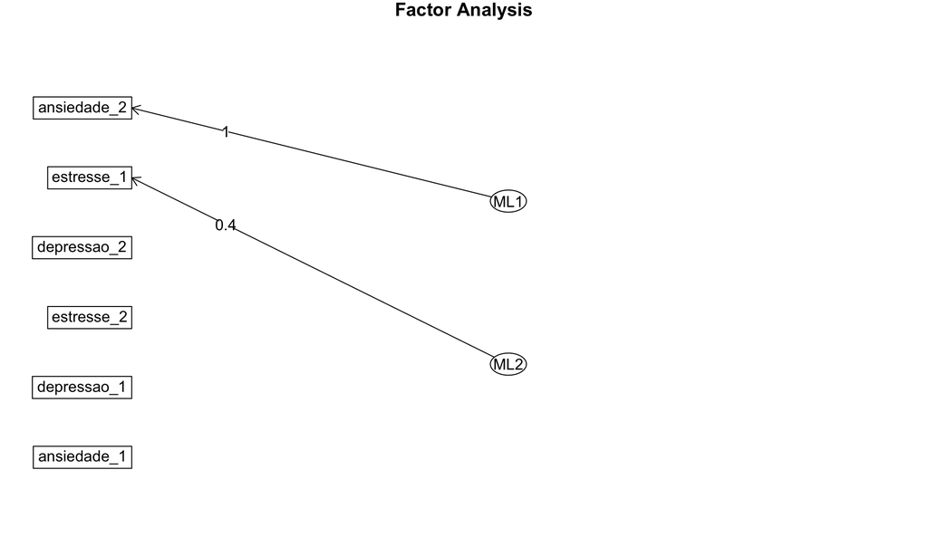

```r
fa.diagram(modelo_efa)
```

## 2.4 Análise Fatorial Confirmatória

```r
# Modelo teórico
modelo_cfa <- '
  saude_mental =~ depressao_1 + depressao_2 + ansiedade_1 + ansiedade_2
  estresse =~ estresse_1 + estresse_2
'

# Ajuste do modelo
ajuste_cfa <- cfa(modelo_cfa, data = dados_saude)

# Sumário do modelo
summary(ajuste_cfa, fit.measures = TRUE)
```

```
## lavaan 0.6-19 ended normally after 80 iterations
##
##   Estimator                                         ML
##   Optimization method                           NLMINB
##   Number of model parameters                        13
##
##   Number of observations                           200
##
## Model Test User Model:
##
##   Test statistic                                 2.417
##   Degrees of freedom                                 8
##   P-value (Chi-square)                           0.965
##
## Model Test Baseline Model:
##
##   Test statistic                                 9.610
##   Degrees of freedom                                15
##   P-value                                        0.844
##
## User Model versus Baseline Model:
##
##   Comparative Fit Index (CFI)                    1.000
##   Tucker-Lewis Index (TLI)                      -0.942
##
## Loglikelihood and Information Criteria:
##
##   Loglikelihood user model (H0)              -1692.247
##   Loglikelihood unrestricted model (H1)      -1691.039
##
##   Akaike (AIC)                                3410.494
##   Bayesian (BIC)                              3453.372
##   Sample-size adjusted Bayesian (SABIC)       3412.187
##
## Root Mean Square Error of Approximation:
##
##   RMSEA                                          0.000
##   90 Percent confidence interval - lower         0.000
##   90 Percent confidence interval - upper         0.000
##   P-value H_0: RMSEA <= 0.050                    0.993
```

[output cut: 23 more lines]

```
## Covariances:
##                    Estimate  Std.Err  z-value  P(>|z|)
##   saude_mental ~~
##     estresse         -0.025    0.041   -0.615    0.538
##
## Variances:
##                    Estimate  Std.Err  z-value  P(>|z|)
##    .depressao_1       0.891    0.092    9.725    0.000
##    .depressao_2       1.093    0.195    5.604    0.000
##    .ansiedade_1       0.927    0.093    9.971    0.000
##    .ansiedade_2       1.096    0.136    8.044    0.000
##    .estresse_1        0.888    0.238    3.739    0.000
##    .estresse_2        0.985    0.117    8.408    0.000
##     saude_mental     -0.006    0.019   -0.335    0.738
##     estresse          0.178    0.228    0.781    0.435
```

# 3 Técnicas Avançadas

## 3.1 Tratamento de Problemas Comuns

### 3.1.1 Dados Não Normais

```r
# Função de transformação
transformar_dados <- function(dados) {
  dados %>%
    mutate(
      log_var = log(abs(dados) + 1),
      sqrt_var = sqrt(abs(dados)),
      box_cox_var = car::powerTransform(dados)
    )
}

# Verificar normalidade
check_normality <- function(dados) {
  sapply(dados, function(x) {
    list(
      assimetria = skew(x),
      curtose = kurtosi(x)
    )
  })
}
```

### 3.1.2 Tratamento de Outliers

```r
detectar_outliers <- function(dados) {
  # Método de Mahalanobis
  maha_dist <- mahalanobis(dados,
                           colMeans(dados),
                           cov(dados))

  limite_outliers <- qchisq(0.975, df = ncol(dados))
  outliers <- which(maha_dist > limite_outliers)

  list(
    outliers = outliers,
    dados_limpos = dados[-outliers, ]
  )
}
```

### 3.1.3 Dados Faltantes

```r
tratar_dados_faltantes <- function(dados) {
  # Imputação múltipla
  dados_imputados <- mice(
    dados,
    m = 5,           # 5 conjuntos imputados
    method = 'pmm',  # Preditive mean matching
    seed = 123
  )

  complete(dados_imputados, 1)
}
```

## 3.2 Métodos de Rotação

```r
rotacoes <- c("varimax", "quartimax", "promax", "oblimin")

comparar_rotacoes <- function(dados, rotacoes) {
  resultados <- lapply(rotacoes, function(rot) {
    modelo <- fa(dados, nfactors = 2, rotate = rot)
    modelo$loadings
  })

  names(resultados) <- rotacoes
  resultados
}

# Aplicar diferentes rotações
resultado_rotacoes <- comparar_rotacoes(dados_saude, rotacoes)
```

# 4 Considerações Finais

## 4.1 Boas Práticas

1. **Validade de Constructo**
   - Garantir representatividade dos fatores
   - Validação por especialistas
2. **Reprodutibilidade**
   - Documentação detalhada
   - Análises em subamostras
3. **Interpretabilidade**
   - Significado clínico/teórico
   - Além dos resultados estatísticos